# Common Tern chick mass: simple version for the non-expert meeting

Plain-language companion to issue #9/#10’s chick mass decline - no jargon, grams only

2026-10-29

# Why this exists

`10_mass_decline_summary.Rmd` shows the Common Tern chick mass decline using normalized metrics (ratio, SMI) for a technical/expert audience. Inbal asked for a version for a meeting with non-experts: same underlying finding, but expressed as a single easy number - **how many grams below average was last year, and how does it rank against other years** - with no “SMI” or “ratio” jargon in the figure itself.

**What “adjusted mass” means here**: chicks are weighed at different ages/sizes, so raw grams alone aren’t comparable across chicks. We adjust each chick’s weight to what it would weigh *at the average wing length for this colony’s chicks* - same idea as “if all chicks were the same size, how much would they weigh.” This is the same underlying normalization (SMI, Peig & Green 2009) used in the full report, just relabeled for a non-technical audience. Numbers will match `10_mass_decline_summary.Rmd`’s Common Tern chick SMI exactly.

# Data

```r
raw_dir <- "../../data_raw"
if (!dir.exists(raw_dir)) raw_dir <- "../data_raw"
if (!dir.exists(raw_dir)) raw_dir <- "data_raw"
stopifnot(dir.exists(raw_dir))

out_dir <- "../output"
if (!dir.exists(out_dir)) out_dir <- "output"

ringing_path <- file.path(raw_dir, "ringing_data_raw.xlsx")
stopifnot(file.exists(ringing_path))

col_names_47 <- c(
  "CR1","RingReplace","Rec","RingPrefix","RingNum","Species","Sex","Age","Wing","Weight",
  "Date","Time","Place","Lat","Lon","Ringer","Country","Remarks","Net","CR2","Subsp","Tail","Head",
  "Breeding","CP1","CP2","CP3","CP4","Colour","D","M","OrigDate","OrigCountry","OrigLat","OrigLon","OrigAge",
  "OldCR1","OldCR2","OldCR3","OldMetal1","OldMetal2","OilHead","OilWings","OilUpperP","OilUnderP","OilLegs","OilSum"
)
raw <- read_excel(ringing_path, sheet = "Data", skip = 2, col_names = col_names_47)

terns <- raw %>%
  filter(Species == "STEHIR") %>%
  mutate(
    year = year(Date),
    month = month(Date),
    is_new = is.na(Rec) | trimws(Rec) == "",
    is_recap = trimws(Rec) == "R" & !is.na(Rec),
    is_capture = is_new | is_recap
  )

chicks <- terns %>%
  filter(is_capture, Age == 3, !is.na(Weight), !is.na(Wing), month %in% 6:8)

wing_mean <- mean(chicks$Wing)
b <- sd(log(chicks$Weight)) / sd(log(chicks$Wing))
chicks <- chicks %>%
  mutate(adj_mass = Weight * (wing_mean / Wing) ^ b)

cat("Common Tern chicks, Jun-Aug, Wing+Weight available: n =", nrow(chicks),
    "across", n_distinct(chicks$year), "years (", min(chicks$year), "-", max(chicks$year), ")\n")
```

```
## Common Tern chicks, Jun-Aug, Wing+Weight available: n = 1274 across 17 years ( 2010 - 2026 )
```

```r
cat("Reference wing length used for adjustment:", round(wing_mean, 1), "mm (colony average)\n")
```

```
## Reference wing length used for adjustment: 244.1 mm (colony average)
```

# Per-year numbers

```r
yearly <- chicks %>%
  group_by(year) %>%
  summarise(n = n(), mean_adj_mass = mean(adj_mass), .groups = "drop") %>%
  arrange(year)

overall_avg <- mean(yearly$mean_adj_mass)
latest_year <- max(yearly$year)
latest_row <- yearly %>% filter(year == latest_year)
latest_mean <- latest_row$mean_adj_mass
deviation <- latest_mean - overall_avg

yearly <- yearly %>%
  mutate(rank_low_to_high = rank(mean_adj_mass, ties.method = "min"))
latest_rank <- yearly$rank_low_to_high[yearly$year == latest_year]
n_years <- nrow(yearly)

kable(yearly %>% mutate(mean_adj_mass = round(mean_adj_mass, 1)),
      col.names = c("Year", "n chicks", "Mean adjusted mass (g)", "Rank (1 = lowest)"),
      caption = "Common Tern chick mass, adjusted to average wing length, by year")
```

Common Tern chick mass, adjusted to average wing length, by year

| Year | n chicks | Mean adjusted mass (g) | Rank (1 = lowest) |
| --- | --- | --- | --- |
| 2010 | 31 | 110.2 | 4 |
| 2011 | 97 | 115.2 | 12 |
| 2012 | 103 | 115.6 | 13 |
| 2013 | 59 | 119.3 | 15 |
| 2014 | 46 | 116.0 | 14 |
| 2015 | 120 | 113.7 | 11 |
| 2016 | 12 | 109.1 | 1 |
| 2017 | 11 | 123.5 | 17 |
| 2018 | 124 | 111.3 | 7 |
| 2019 | 137 | 113.0 | 9 |
| 2020 | 171 | 109.5 | 2 |
| 2021 | 66 | 113.5 | 10 |
| 2022 | 80 | 111.1 | 6 |
| 2023 | 129 | 111.9 | 8 |
| 2024 | 33 | 121.7 | 16 |
| 2025 | 15 | 111.0 | 5 |
| 2026 | 40 | 109.6 | 3 |

```r
ordinal <- function(n) {
  if (n %% 100 %in% 11:13) return(paste0(n, "th"))
  switch(as.character(n %% 10), "1" = paste0(n, "st"), "2" = paste0(n, "nd"),
         "3" = paste0(n, "rd"), paste0(n, "th"))
}

cat(sprintf(
  "\n%d: mean adjusted chick mass = %.1f g\n%d-year average = %.1f g\n%s is %.1f g %s the %d-year average\n%s is the %s-lowest of %d years on record (1 = lowest ever)\n",
  latest_year, latest_mean, n_years, overall_avg,
  latest_year, abs(deviation), ifelse(deviation < 0, "below", "above"), n_years,
  latest_year, ordinal(latest_rank), n_years
))
```

```
##
## 2026: mean adjusted chick mass = 109.6 g
## 17-year average = 113.8 g
## 2026 is 4.2 g below the 17-year average
## 2026 is the 3rd-lowest of 17 years on record (1 = lowest ever)
```

# Plot (for the meeting slide)

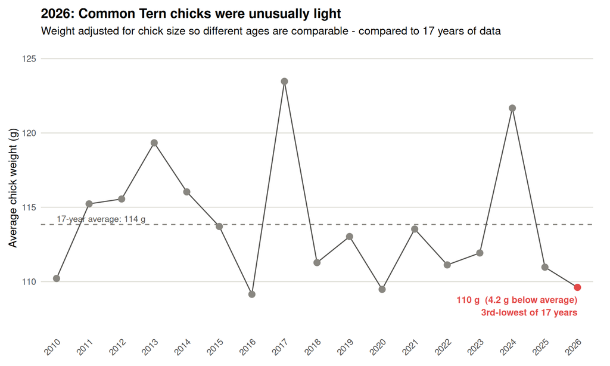

```r
# Trend-over-time job -> line/point form, not bars: a bar chart would force
# the y-axis to start at 0, which would visually flatten this real ~4%
# decline into near-nothing. Position (not bar length) carries the value, so
# a zoomed-in axis here is honest, not misleading.
yearly_plot <- yearly %>%
  mutate(is_latest = year == latest_year,
         point_group = ifelse(is_latest, "This year", "Other years"))

y_range <- range(yearly_plot$mean_adj_mass)
y_pad <- 0.12 * diff(y_range)

p <- ggplot(yearly_plot, aes(x = year, y = mean_adj_mass)) +
  geom_hline(yintercept = overall_avg, linetype = "dashed", linewidth = 0.6, color = "#898781") +
  geom_line(color = "#52514e", linewidth = 0.6) +
  geom_point(aes(color = point_group), size = 3.2) +
  annotate("text", x = min(yearly_plot$year), y = overall_avg + 0.1 * y_pad,
           label = sprintf("17-year average: %.0f g", overall_avg),
           hjust = 0, vjust = 0, size = 3.6, color = "#52514e") +
  annotate("text", x = latest_year, y = latest_mean - 0.35 * y_pad,
           label = sprintf("%.0f g  (%.1f g below average)\n%s-lowest of %d years",
                            latest_mean, abs(deviation), ordinal(latest_rank), n_years),
           hjust = 1, vjust = 1, size = 3.8, fontface = "bold", color = "#e34948", lineheight = 1.15) +
  scale_color_manual(values = c("This year" = "#e34948", "Other years" = "#898781")) +
  scale_x_continuous(breaks = yearly_plot$year, expand = expansion(mult = c(0.03, 0.03))) +
  coord_cartesian(ylim = c(y_range[1] - y_pad, y_range[2] + y_pad), clip = "off") +
  labs(title = sprintf("%d: Common Tern chicks were unusually light", latest_year),
       subtitle = "Weight adjusted for chick size so different ages are comparable - compared to 17 years of data",
       x = NULL, y = "Average chick weight (g)", color = NULL) +
  theme_minimal(base_size = 13) +
  theme(legend.position = "none",
        panel.grid.minor = element_blank(),
        panel.grid.major.x = element_blank(),
        panel.grid.major.y = element_line(color = "#e1e0d9"),
        axis.text.x = element_text(angle = 45, hjust = 1),
        plot.title = element_text(face = "bold"),
        plot.margin = margin(10, 20, 10, 10))
p
```

```r
ggsave(file.path(out_dir, "11_chick_mass_for_meeting.png"), p, width = 10, height = 6, dpi = 300)
```